# Structural topic models

Loading packages:

```r
#install.packages("stm")
#install.packages("lubridate")
#install.packages("wordcloud")
#install.packages("LDAvis")
library("quanteda")
library("stm")
library("stringi")
library("lubridate")
```

## Text processing

In this notebook, we will illustrate functionalities of structural topic models with the help of a random sample of 10,000 public Facebook posts by members of the U.S. Congress from 2017. With this data, we will use and explore code examples from the `stm` package [vignette](https://cran.r-project.org/web/packages/stm/vignettes/stmVignette.pdf). Loading the data:

```r
df <- read.csv("data/fb-congress-data.csv")
df$message <- stri_unescape_unicode(df$message) # unescaping unicodes
colnames(df)
```

```
##  [1] "screen_name"    "date"           "post_type"      "message"
##  [5] "likes_count"    "comments_count" "shares_count"   "love_count"
##  [9] "haha_count"     "wow_count"      "angry_count"    "sad_count"
## [13] "gender"         "type"           "party"
```

Processing it:

```r
# Keeping only two main parties
df <- df[df$party %in% c("Democrat", "Republican"), ]

# Keeping only the relevant columns
df <- df[, colnames(df) %in% c("screen_name","date","message","gender","party")]

# Drop observations with missing values
df <- na.omit(df)

# Creating a day of the year column
df$date <- as_datetime(df$date)
df$day_of_year <- yday(df$date)

# Transforming gender and party into factors
df$gender <- factor(df$gender)
df$party <- factor(df$party)
# Specifying a specific order of factors
# This makes Republican being label 1 and democrat being label 2
df$party <- factor(df$party, levels = c("Republican", "Democrat"))
nrow(df)
```

```
## [1] 9634
```

```r
head(df)
```

```
##            screen_name       date
## 1         RepEspaillat 2017-05-18
## 2 CongressmanCulberson 2017-06-27
## 3         RepAndyBiggs 2017-05-07
## 4         derek.kilmer 2017-12-22
## 5    CongressmanNadler 2017-02-28
## 6     repsaludcarbajal 2017-04-19
##                                                                                                                                                                                                                                                                                                          …
## 1                                                                                                                                                                                                                                                                                                        …
## 2                                                                                                                                                                                                                                                                                                        …
## 3                                                         Today is the end of Small Business Week, and I commend the thousands of men and women in my district who are small business owners. Small businesses create 63% of new jobs in this country, and almost 50% of private sector employees work fo…
## 4 I voted against the continuing resolution today.  I am disappointed that rather than using these last few weeks to do their jobs and produce a long-term, bipartisan spending plan, the majority of Congress has decided to once again kick the can down the road. I remain committed to working with t…
## 5                                                                                                                                                                                                                                                                                                        …
## 6                                                                                                                                                                                                                                                                                                        …
##   gender      party day_of_year
## 1      M   Democrat         138
## 2      M Republican         178
## 3      M Republican         127
## 4      M   Democrat         356
## 5      M   Democrat          59
## 6      M   Democrat         109
```

Creating a corpus and document feature matrix with `quanteda`:

```r
posts_corpus <- corpus(df$message,
                       docvars = df[,c("screen_name", "date", "day_of_year",
                                       "gender", "party")])
```

```r
posts_dfm <- posts_corpus %>%
  tokens(remove_punct = TRUE, remove_numbers = TRUE, remove_symbols = TRUE,
         remove_url = TRUE) %>%
  tokens_remove(stopwords("en"), padding = TRUE) %>%
  tokens_ngrams(n = 1:2) %>%
  dfm() %>%
  dfm_trim(min_termfreq = 5)
posts_dfm
```

```
## Document-feature matrix of: 9,634 documents, 10,273 features (99.7% sparse) and 5 docvars.
##        features
## docs    morning year month honor name may three police come officers
##   text1       0    1     4     0    0   1     0      0    1        0
##   text2       0    0     0     1    0   0     0      0    0        0
##   text3       0    0     0     0    0   0     0      0    0        0
##   text4       0    0     0     0    0   0     1      0    0        0
##   text5       0    0     0     0    0   0     0      0    0        0
##   text6       1    0     0     0    0   0     0      0    0        0
## [ reached max_ndoc ... 9,628 more documents, reached max_nfeat ... 10,263 more features ]
```

Converting the `quanteda` object into an input for the structural topic model:

```r
stm_input <- convert(posts_dfm, to = "stm")
```

## Fitting a topic model with topic prevalence covariates

To obtain some quantitative diagnostics, you can run a code chunk like the following, however, it can run for several hours already on a dataset of this size. You could run it after this coding sessions for a smaller set of K values to try it out.

```r
k_search_output <- searchK(stm_input$documents, stm_input$vocab,
                           K = c(5, 10, 25, 50, 100), data = stm_input$meta,
                           verbose = FALSE, heldout.seed = 123)
plot(k_search_output)
k_search_output
```

For this notebook, we will choose K=50 because this value allows to illustrate certain cases in this example. When estimating the topic model, we provide a smoothed version of the day of the year and the politician’s party as topic prevalence covariates and do not specify any topic content covariates for now. Already estimating this one model will take some time on the approximately 9,600 documents.

```r
stmodel <- stm(documents = stm_input$documents, vocab = stm_input$vocab,
                     K = 50, prevalence =~ party + s(day_of_year),
               data = stm_input$meta, verbose = FALSE, init.type = "Spectral")
```

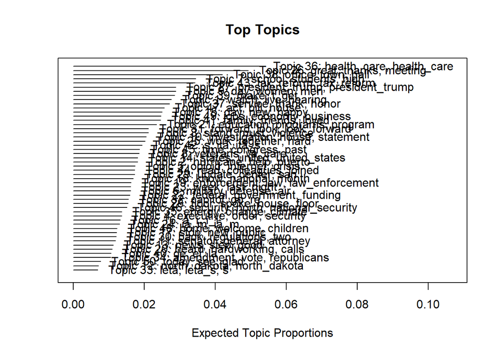

```r
# fig1
plot(stmodel)
```

Even with the minimal tuning, the model detects a lot of structure and some interesting topics. For example:

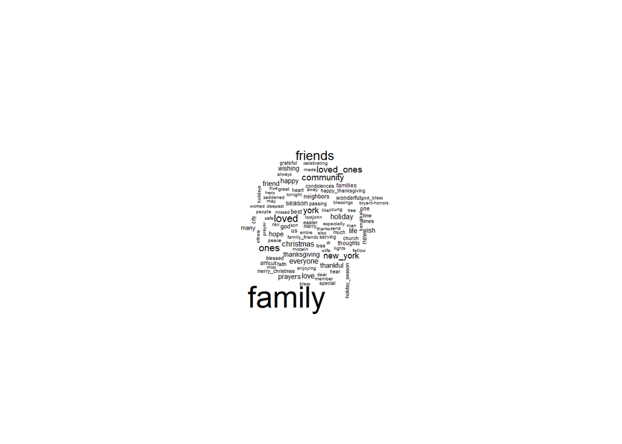

```r
cloud(stmodel, topic = 41, scale = c(2,.25))
```

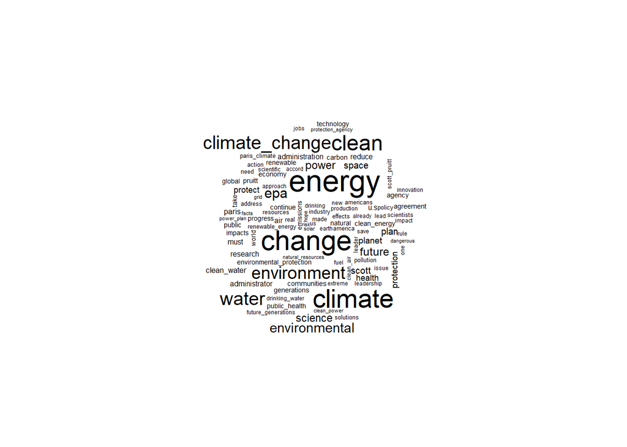

```r
cloud(stmodel, topic = 35, scale = c(2,.25))
```

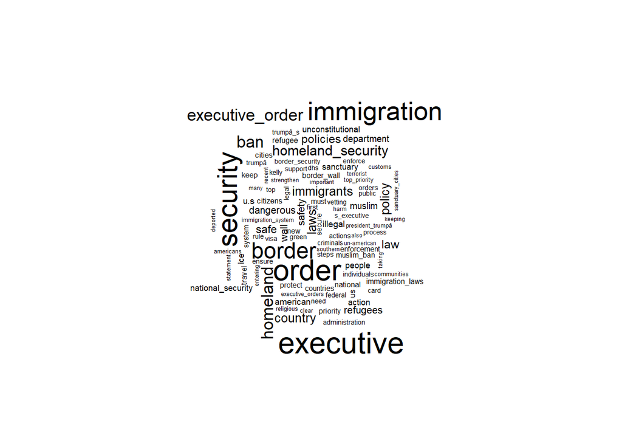

```r
cloud(stmodel, topic = 4, scale = c(2,.25))
```

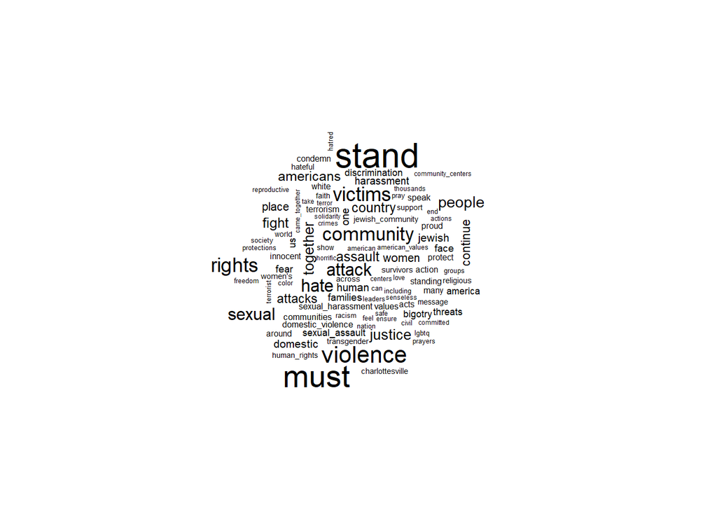

```r
cloud(stmodel, topic = 3, scale = c(2,.25))
```

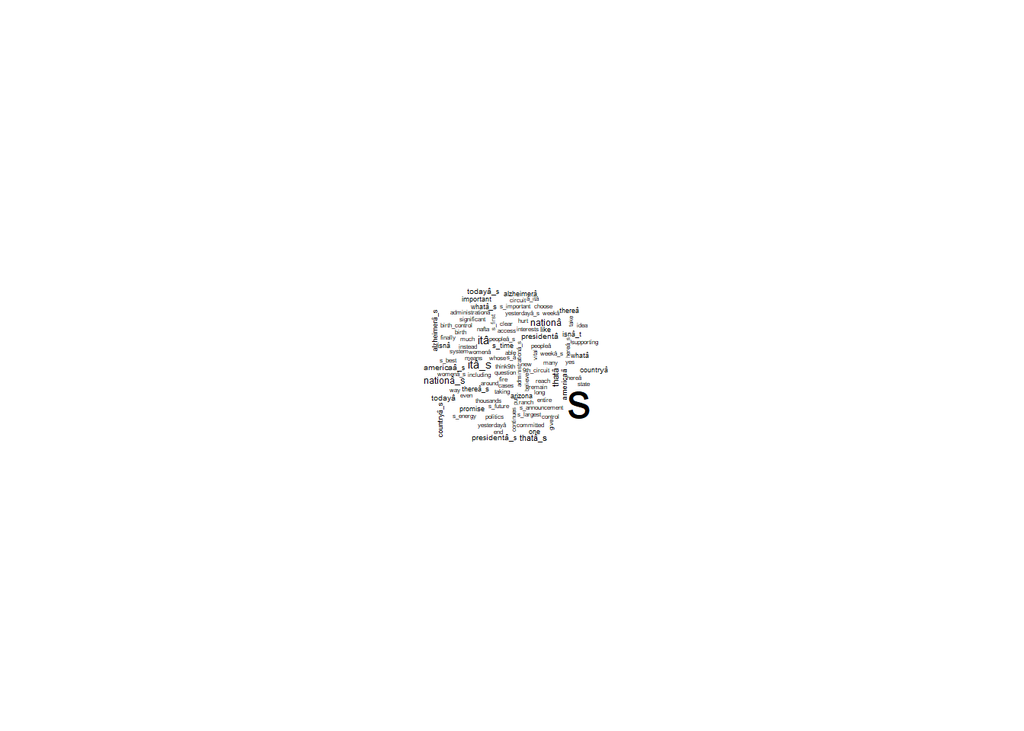

```r
cloud(stmodel, topic = 42, scale = c(2,.25))
```

Let us now look into documents which have high shares of these topics and see whether the topic assignment makes sense. This can be done with the function `findThoughts`. We will look at only 2 examples to illustrate the functionality, but of course reading of more articles would be necessary for a careful analysis.

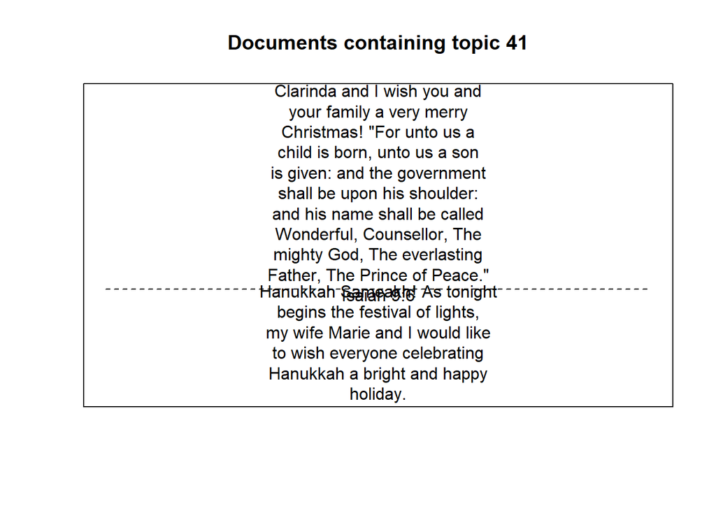

```r
health_care_articles <- findThoughts(stmodel,
                                     texts = df$message[rowSums(posts_dfm)>0],
                                     n = 2, topics = 41)$docs[[1]]
plotQuote(health_care_articles, width = 30,
          main = "Documents containing topic 41")
```

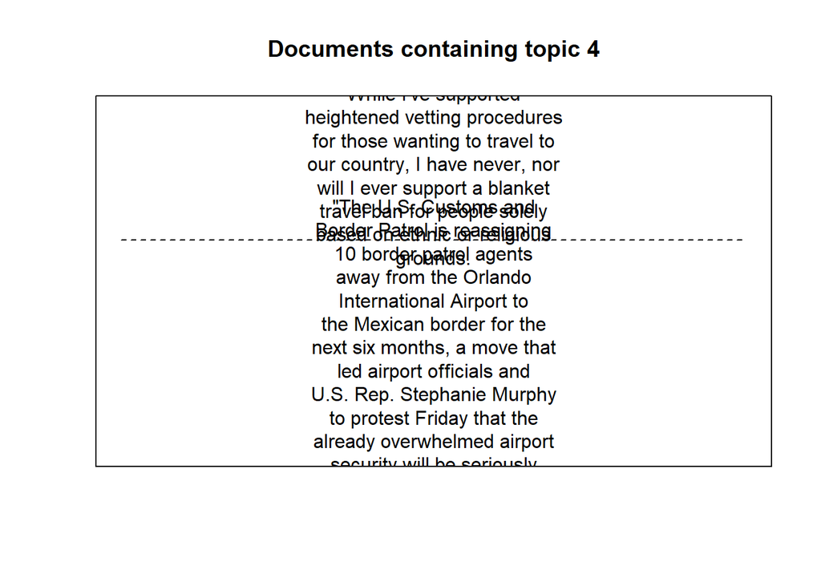

```r
topic_4_articles <- findThoughts(stmodel,
                                 texts = df$message[rowSums(posts_dfm)>0],
                                 n = 2, topics = 4)$docs[[1]]
plotQuote(topic_4_articles, width = 30, main = "Documents containing topic 4")
```

This emphasizes the importance of such an analysis when fitting, evaluating, and calibrating different topic models for a project or paper.

Another great feature of the structural topic model package is that the prevalence covariates allow to see which topics are discussed more by which of the two groups:

```r
# 1:50 refers to topic 1-50
effect_estimates <- estimateEffect(1:50 ~ party + s(day_of_year), stmodel, meta = stm_input$meta)
```

[figure not shown]

```r
plot(effect_estimates, covariate = "party", topics = c(41, 35, 3, 42),
     model = stmodel, method = "difference",
     cov.value1 = "Republican", cov.value2 = "Democrat",
     xlab = "More Democrat ... More Republican",
     main = "Democrats and Republicans",
     xlim = c(-.1, .1), labeltype = "custom",
     custom.labels = c("Health care", "Russia investigation",
                       "Immigration and border", "Law enforcement"))
```

[figure not shown]

```r
plot(effect_estimates, "day_of_year", method = "continuous", topics = 41,
     model = stmodel, printlegend = FALSE, xaxt = "n", xlab = "2017",
     main = "Health care topic over time")
monthseq <- seq(from = as.Date("2017-01-01"), to = as.Date("2017-12-01"),
                by = "month")
monthnames <- months(monthseq)
axis(1, at = as.numeric(monthseq) - min(as.numeric(monthseq)),
     labels = monthnames)
```

Lastly, let us illustrate a very helpful interactive tool called LDAvis which allows to explore topic models:

```r
toLDAvis(stmodel, docs = stm_input$documents)
```

## Fitting a topic model with topic prevalence and topic content covariates

Next, we fit another structural topic model with both prevalence and topic content covariates. This allows to not just analyse how topic shares within documents vary cross different groups, but also how words in topics vary. The following will take a longer time to run than the previous model because of the additional covariate.

```r
stmodel_additional_content_variable <- stm(documents = stm_input$documents,
                                           vocab = stm_input$vocab, K = 50,
                                           prevalence = ~ party + s(date),
                                           content = ~ party,
                                           data = stm_input$meta,
                                           verbose = FALSE,
                                           init.type = "Spectral")
```

Note that this has estimated an new model, so words in topics will be different:

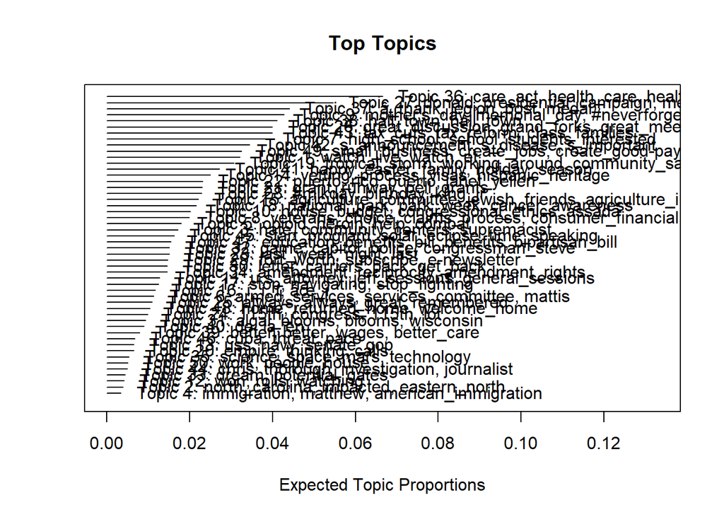

```r
plot(stmodel_additional_content_variable)
```

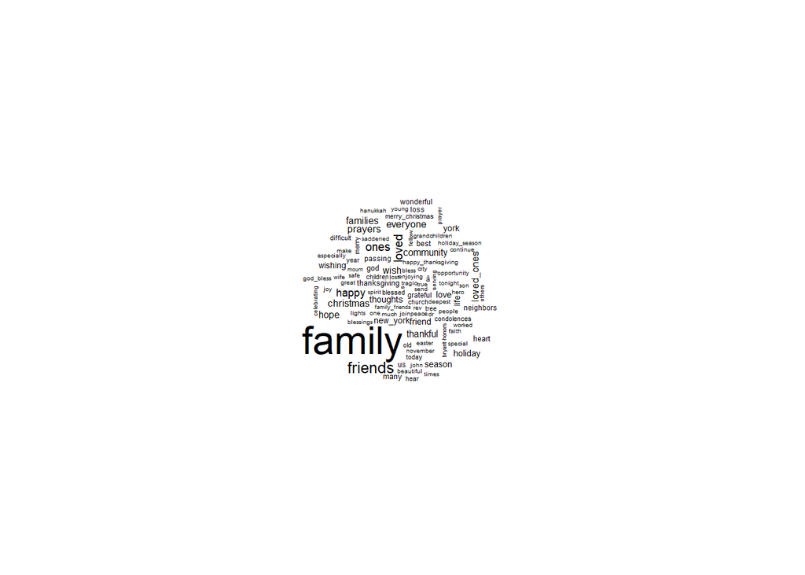

```r
cloud(stmodel_additional_content_variable, topic = 41, scale = c(2,.25))
```

With the help of the new content covariate, we can now analyse how the two parties discuss the same topic differently:

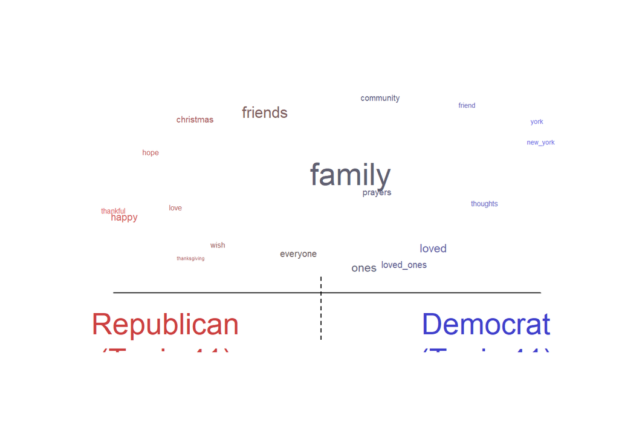

```r
plot(stmodel_additional_content_variable, type = "perspectives", topics = 41)
```

For other topics, however, the results are less reasonable. While the purpose of this notebook is to illustrate a range of functionalities of (structural) topic models with real world data, it also emphasizes how important careful model selection and evaluation are in final papers or projects such as http://j.mp/lda-congress-demo. Some exemplary areas and questions that could be explored here would be:

- Aggregation of short documents similarly to Barberá et al. (2014)
- Choosing different amounts of K based on careful analysis of topic coherence, reading of documents with regard to their topic allocation, and quantitative model evaluation
- Trying different topic models which might be better suited for short text, see e.g. Bauer et al., Political Behavior, 2017 (the `stm` package e.g. also allows to estimate a SAGE model)
- Could different sets of topic prevalence and topic content covariates be helpful, or could some covariates be dropped for the analysis?
- Is a structural topic model necessary for a certain research question, or could a plain correlated topic model (i.e. no covariates added) be an option?
- Different pre-processing, e.g. dropping more terms with the options in the function `dfm_trim`
- Using a larger corpus with many more than the sample of ~10,000 posts (implies, however, that model estimation would take much longer)
- etc.

For a discussion of model selection and evaluation for structural topic models (e.g. different initialisations, covariates, values of K), see also e.g. Section “3.4. Evaluate: Model selection and search” the package [vignette](https://cran.r-project.org/web/packages/stm/vignettes/stmVignette.pdf) or the Section *Model Specification and Selection* in ``Structural Topic Models for Open-Ended Survey Responses'' by Roberts et al. (2014). References - This notebook is based on code from the vignette of the`stm` package https://cran.r-project.org/web/packages/stm/vignettes/stmVignette.pdf. See the vignette also for further functionalities of the package